# 08-Machine-Learning-Assignment

## Introduction

Using devices such as Jawbone Up, Nike FuelBand, and Fitbit it is now possible to collect a large amount of data about personal activity relatively inexpensively. These type of devices are part of the quantified self movement – a group of enthusiasts who take measurements about themselves regularly to improve their health, to find patterns in their behavior, or because they are tech geeks. One thing that people regularly do is quantify how much of a particular activity they do, but they rarely quantify how well they do it. In this project, the goal is to use data from accelerometers on the belt, forearm, arm, and dumbell of 6 participants. They were asked to perform barbell lifts correctly and incorrectly in 5 different ways. More information is available from the website here: http://groupware.les.inf.puc-rio.br/har (see the section on the Weight Lifting Exercise Dataset).

The goal of this project is to predict the manner in which the 6 participants did the exercise. This is the “classe” variable in the training set.

## Data and preprocessing

```r
library(lattice); library(ggplot2); library(caret)

data <- read.csv("pml-training.csv", header=TRUE)
summary(data$classe)
```

```
##    A    B    C    D    E
## 5580 3797 3422 3216 3607
```

The classe distribution of the overall data is shown here:

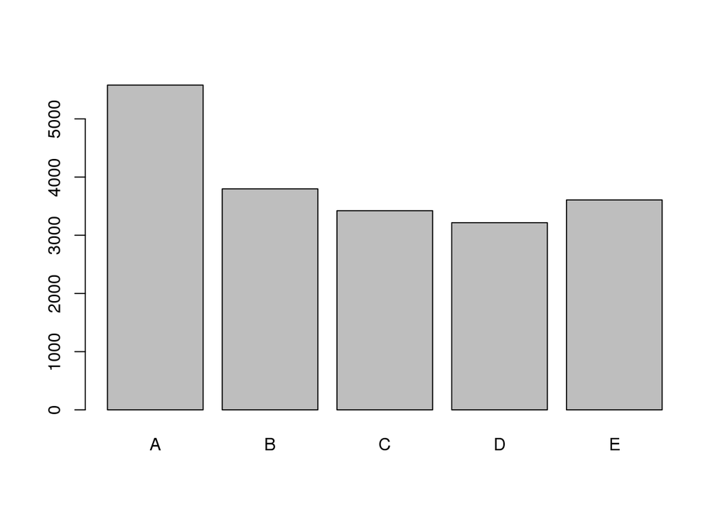

During prepocessing, all variables containing NAs are removed. In a second step, variables with near zero variance are removed, as well as the first variables containing only structural information (e.g. user name and timestaps)

```r
print(dim(data))
```

```
## [1] 19622   160
```

```r
bad <- sapply(data, function(x) any(is.na(x)))
data <- data[,!bad]
print(dim(data))
```

```
## [1] 19622    93
```

```r
nearzeros <- nearZeroVar(data,saveMetrics=TRUE)
data <- data[,!(nearzeros$nzv)]
data <- data[,-c(1:6)]
```

```r
nums <- sapply(data, function(x) all(is.numeric(x)))
preObj <- preProcess (data[,nums],method= c ("center","scale"))
```

## K-fold cross validation with rpart2

As one can see, the accuracy is about 56 per cent, the “in sample” error beeing 44 per cent. I assume the “out of sample” error to be worse, so I assume an accuracy of about 50 per cent and an “out of sample” error of 50 per cent as well. [As I have seen in the second part of the assignment, I was able to predict 8 of 20 test cases right, so the out of sample error for this test set is 60 per cent.]

```r
# First: k-fold
train_control <- trainControl(method="cv", number=10)
model <- train(classe~., data=data, trControl=train_control, method="rpart2")
predictions <- predict(model, data)
m <- confusionMatrix(predictions, data$classe)
print(m)
```

```
## Confusion Matrix and Statistics
##
##           Reference
## Prediction    A    B    C    D    E
##          A 5080 1581 1587 1449  524
##          B   81 1174  106   37  129
##          C  282  407 1478  449  431
##          D  123  635  251 1281  610
##          E   14    0    0    0 1913
##
## Overall Statistics
##
##                Accuracy : 0.5568
##                  95% CI : (0.5498, 0.5638)
##     No Information Rate : 0.2844
##     P-Value [Acc > NIR] : < 2.2e-16
##
##                   Kappa : 0.4225
##  Mcnemar's Test P-Value : < 2.2e-16
##
## Statistics by Class:
##
##                      Class: A Class: B Class: C Class: D Class: E
## Sensitivity            0.9104  0.30919  0.43191  0.39832  0.53036
## Specificity            0.6339  0.97769  0.90315  0.90132  0.99913
## Pos Pred Value         0.4970  0.76883  0.48507  0.44172  0.99273
## Neg Pred Value         0.9468  0.85504  0.88271  0.88428  0.90427
## Prevalence             0.2844  0.19351  0.17440  0.16390  0.18382
## Detection Rate         0.2589  0.05983  0.07532  0.06528  0.09749
## Detection Prevalence   0.5209  0.07782  0.15528  0.14779  0.09821
## Balanced Accuracy      0.7721  0.64344  0.66753  0.64982  0.76474
```

## Prediction

Finally, the trained model is used for prediction of the classe variable for the testing data.

```r
data <- read.csv("pml-testing.csv", header=TRUE)
predictionsfinal <- predict(model, data)
print(predictionsfinal)
```

```
##  [1] C A D A A C D A A A C D C A D A A A A D
## Levels: A B C D E
```

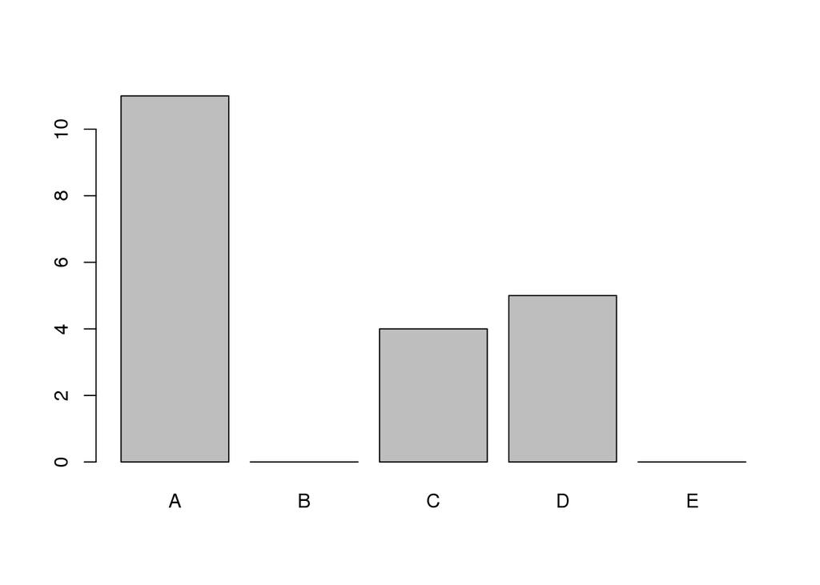